# UNICEF Malaria Testing: A Global Challenge for Children Under 5

Author

Abhishek Reddy Devarapally

# The Global Challenge of Malaria Testing in Children

## Executive Summary

Malaria remains one of the most significant public health challenges in many parts of the world, particularly affecting children under five years of age. Early diagnosis through proper testing is crucial for effective treatment and prevention of complications. This report analyzes UNICEF data on malaria testing rates for children under five across multiple countries, examining trends over time, geographical patterns, and relationships with socioeconomic factors.

The analysis reveals **significant disparities** in malaria testing rates among different regions and countries, with some nations demonstrating remarkable progress while others lag behind. We also identify important correlations between economic indicators, healthcare infrastructure, and malaria testing rates that provide valuable insights for policymakers and healthcare organizations.

## Data Overview and Preparation

```python
# Load the UNICEF data
df = pd.read_csv('Cleaned_UNICEF_Data.csv')

# Display basic info about the dataset
print(f"Dataset shape: {df.shape}")
print(f"Number of countries: {df['Country'].nunique()}")
print(f"Year range: {df['Year'].min()} to {df['Year'].max()}")

# Display the first few rows
df.head()
```

```
Dataset shape: (423, 19)
Number of countries: 55
Year range: 2009 to 2023
```

|  | Unnamed: 0 | Country | Year | Malaria_Test_Percent | Sex | Age_Group | alpha_2_code | alpha_3_code | numeric_code | Population, total | GDP per capita (constant 2015 US$) | GNI (current US$) | Inflation, consumer prices (annual %) | Life expectancy at birth, total (years) | Military expenditure (% of GDP) | Fossil fuel energy consumption (% of total) | GDP growth (annual %) | Birth rate, crude (per 1,000 people) | Hospital beds (per 1,000 people) |
| --- | --- | --- | --- | --- | --- | --- | --- | --- | --- | --- | --- | --- | --- | --- | --- | --- | --- | --- | --- |
| 0 | 0 | Afghanistan | 2023 | 11.4 | Female | Under 5 years old | AF | AFG | 4.0 | 41454761.0 | 379.707497 | 1.731538e+10 | NaN | NaN | NaN | NaN | 2.710887 | NaN | NaN |
| 1 | 1 | Afghanistan | 2023 | 11.5 | Male | Under 5 years old | AF | AFG | 4.0 | 41454761.0 | 379.707497 | 1.731538e+10 | NaN | NaN | NaN | NaN | 2.710887 | NaN | NaN |
| 2 | 2 | Afghanistan | 2015 | 7.9 | Total | Under 5 years old | AF | AFG | 4.0 | 33831764.0 | 565.569730 | 1.924950e+10 | -0.661709 | 62.659 | 0.994576 | NaN | 1.451315 | 38.803 | 0.44 |
| 3 | 3 | Afghanistan | 2023 | 11.5 | Total | Under 5 years old | AF | AFG | 4.0 | 41454761.0 | 379.707497 | 1.731538e+10 | NaN | NaN | NaN | NaN | 2.710887 | NaN | NaN |
| 4 | 4 | Angola | 2011 | 27.0 | Female | Under 5 years old | AO | AGO | 24.0 | 24218352.0 | 3099.942290 | 1.020924e+11 | 13.482468 | 57.596 | 3.255660 | 43.849784 | 3.472053 | 44.364 | NaN |

```python
# Create summary statistics
summary = df.groupby('Country')['Malaria_Test_Percent'].agg(['mean', 'min', 'max', 'count']).sort_values('mean', ascending=False)
summary.columns = ['Average Testing Rate (%)', 'Minimum Rate (%)', 'Maximum Rate (%)', 'Number of Records']

# Display top 10 countries by average testing rate
summary.head(10)
```

| Country | Average Testing Rate (%) | Minimum Rate (%) | Maximum Rate (%) | Number of Records |
| --- | --- | --- | --- | --- |
| Sudan | 57.400000 | 52.8 | 62.0 | 3 |
| Equatorial Guinea | 45.900000 | 43.5 | 48.3 | 3 |
| Zambia | 43.020000 | 16.4 | 64.4 | 15 |
| Liberia | 41.542857 | 23.4 | 50.9 | 14 |
| Mozambique | 40.320000 | 29.7 | 51.2 | 10 |
| Sierra Leone | 39.680000 | 24.6 | 51.1 | 10 |
| Tanzania, United Republic of | 39.411111 | 22.9 | 54.3 | 9 |
| Solomon Islands | 38.666667 | 37.2 | 40.3 | 3 |
| Malawi | 38.328571 | 17.4 | 56.5 | 14 |
| Uganda | 36.636364 | 17.1 | 52.0 | 11 |

## Data Preprocessing

```python
# Filter for rows with 'Total' sex to avoid duplication in some visualizations
df_total = df[df['Sex'] == 'Total']

# Create a new dataframe with the latest data for each country
latest_data = df_total.sort_values('Year').groupby('Country').tail(1).copy()

# Instead of using geodatasets, use geopandas direct download
url = "https://naciscdn.org/naturalearth/110m/cultural/ne_110m_admin_0_countries.zip"
world = gpd.read_file(url)

# Check column names to identify the country name column
print("World shapefile columns:", world.columns.tolist())

# Rename the country name column to 'Country' for merging with our dataset
world = world.rename(columns={'NAME': 'Country'})

# Some countries might have different names in the datasets, create a mapping
country_mapping = {
    'Tanzania': 'Tanzania, United Republic of',
    'Democratic Republic of the Congo': 'Congo, Democratic Republic of the',
    'Republic of the Congo': 'Congo',
    'United States of America': 'United States',
    # Add more mappings if needed based on your data
}

# Apply mapping to the world dataframe (not our data)
world['Country'] = world['Country'].replace(country_mapping)

# Merge the world geometry with our data for mapping
world_data = world.merge(latest_data, on='Country', how='left')

# Check how many countries were successfully matched
matched_countries = world_data.dropna(subset=['Malaria_Test_Percent'])
print(f"Successfully matched {len(matched_countries)} countries")
```

```
World shapefile columns: ['featurecla', 'scalerank', 'LABELRANK', 'SOVEREIGNT', 'SOV_A3', 'ADM0_DIF', 'LEVEL', 'TYPE', 'TLC', 'ADMIN', 'ADM0_A3', 'GEOU_DIF', 'GEOUNIT', 'GU_A3', 'SU_DIF', 'SUBUNIT', 'SU_A3', 'BRK_DIFF', 'NAME', 'NAME_LONG', 'BRK_A3', 'BRK_NAME', 'BRK_GROUP', 'ABBREV', 'POSTAL', 'FOR…
Successfully matched 45 countries
```

## Global Distribution of Malaria Testing Rates

The map below shows the geographical distribution of malaria testing rates for children under five years old across the world. Countries in darker shades have higher testing rates, while lighter shades indicate lower rates. Grey areas represent countries where data is not available.

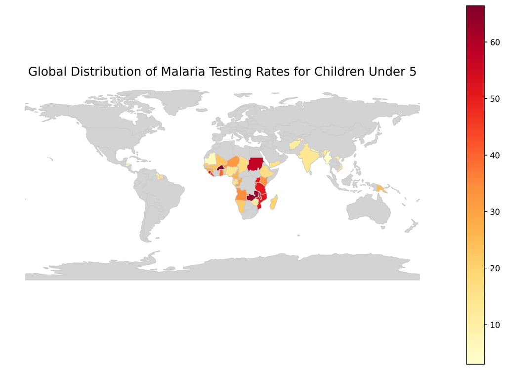

Global Distribution of Malaria Testing Rates for Children Under 5

```python
# Create a world map visualization with plotnine
# First convert the GeoDataFrame to a regular DataFrame for plotting with plotnine
world_data_df = pd.DataFrame({
    'Country': world_data['Country'],
    'Malaria_Test_Percent': world_data['Malaria_Test_Percent'],
    'geometry': world_data['geometry']
})

# Create a matplotlib figure for the map
fig, ax = plt.subplots(1, 1, figsize=(12, 8))

# Plot countries with data
world_data.plot(column='Malaria_Test_Percent',
               cmap='YlOrRd',
               linewidth=0.8,
               ax=ax,
               edgecolor='0.8',
               legend=True,
               missing_kwds={'color': 'lightgrey'})

# Add a title and remove axis
ax.set_title('Global Distribution of Malaria Testing Rates for Children Under 5', fontsize=15)
ax.set_axis_off()

# Show the plot
plt.show()
```

### Key Observations from the Map

- **Geographical Concentration**: Malaria testing data is primarily available from African countries, reflecting the continent’s higher malaria burden.
- **Regional Variations**: There are significant variations in testing rates even among neighboring countries, suggesting differences in healthcare systems and priorities.
- **Data Gaps**: Many countries in Asia, Europe, and the Americas have no data available, which may indicate either lower malaria prevalence or gaps in reporting.

## Leading Countries in Malaria Testing

The following bar chart shows the top 10 countries with the highest malaria testing rates based on the most recent data available for each country.

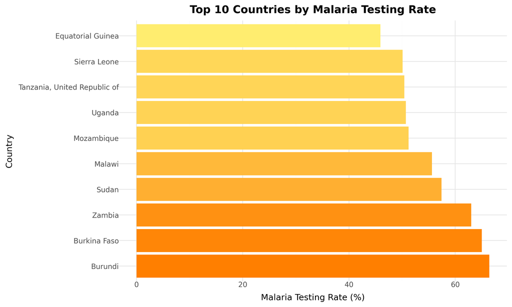

```python
# Select top 10 countries by malaria testing rate
top10_countries = latest_data.sort_values('Malaria_Test_Percent', ascending=False).head(10)

# Create bar chart with plotnine
bar_chart = (
    ggplot(top10_countries, aes(x='reorder(Country, -Malaria_Test_Percent)', y='Malaria_Test_Percent', fill='Malaria_Test_Percent')) +
    geom_bar(stat='identity', show_legend=False) +
    scale_fill_gradient(low='#ffed6f', high='#ff7f00') +
    coord_flip() +
    labs(
        title='Top 10 Countries by Malaria Testing Rate',
        x='Country',
        y='Malaria Testing Rate (%)'
    ) +
    theme_minimal() +
    theme(
        plot_title=element_text(size=15, face='bold'),
        axis_text=element_text(size=10),
        axis_title=element_text(size=12),
        figure_size=(10, 6)
    )
)

# This will actually display the plot
bar_chart.draw()
```

## Relationship Between Economic Factors and Malaria Testing

Understanding the relationship between economic development and healthcare outcomes is crucial. The scatter plot below explores the correlation between GDP per capita and malaria testing rates, with additional dimensions showing population size and life expectancy.

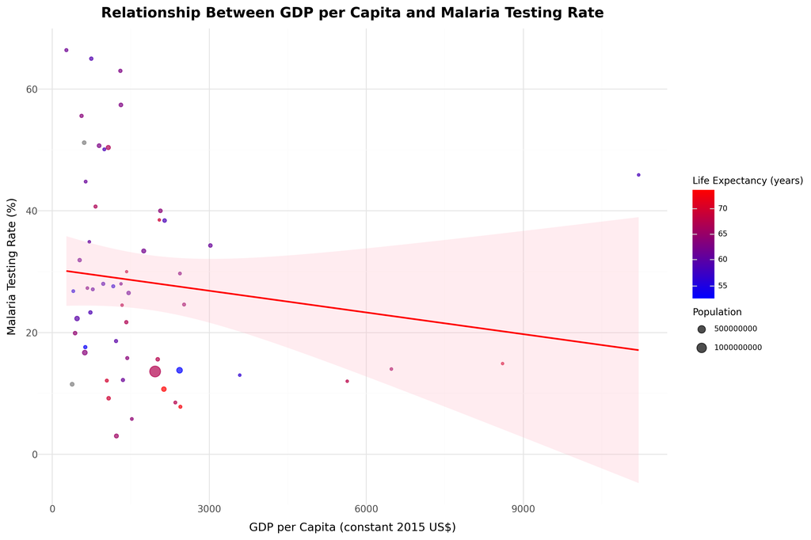

Relationship Between GDP per Capita and Malaria Testing Rate

```python
# Filter out countries with missing GDP data
gdp_data = latest_data.dropna(subset=['GDP per capita (constant 2015 US$)', 'Malaria_Test_Percent'])

# Create scatter plot with regression line
scatter_plot = (
    ggplot(gdp_data, aes(x='GDP per capita (constant 2015 US$)', y='Malaria_Test_Percent')) +
    geom_point(aes(size='Population, total', color='Life expectancy at birth, total (years)'), alpha=0.7) +
    geom_smooth(method='lm', color='red', fill='pink', alpha=0.3) +
    scale_color_gradient(low='blue', high='red') +
    labs(
        title='Relationship Between GDP per Capita and Malaria Testing Rate',
        x='GDP per Capita (constant 2015 US$)',
        y='Malaria Testing Rate (%)',
        color='Life Expectancy (years)',
        size='Population'
    ) +
    theme_minimal() +
    theme(
        plot_title=element_text(size=15, face='bold'),
        axis_text=element_text(size=10),
        axis_title=element_text(size=12),
        legend_title=element_text(size=10),
        legend_text=element_text(size=8),
        figure_size=(12, 8)
    )
)

# Just call the object to render
scatter_plot.draw()
```

```python
# Perform regression analysis
from statsmodels.formula.api import ols
model = ols('Malaria_Test_Percent ~ Q("GDP per capita (constant 2015 US$)")', data=gdp_data).fit()
print(model.summary())
```

```
                             OLS Regression Results
================================================================================
Dep. Variable:     Malaria_Test_Percent   R-squared:                       0.021
Model:                              OLS   Adj. R-squared:                  0.002
Method:                   Least Squares   F-statistic:                     1.096
Date:                  Sun, 27 Apr 2025   Prob (F-statistic):              0.300
Time:                          16:26:09   Log-Likelihood:                -226.89
No. Observations:                    54   AIC:                             457.8
Df Residuals:                        52   BIC:                             461.8
Df Model:                             1
Covariance Type:              nonrobust
===========================================================================================================
                                              coef    std err          t      P>|t|      [0.025      0.975]
-----------------------------------------------------------------------------------------------------------
Intercept                                  30.4300      3.050      9.978      0.000      24.310      36.550
Q("GDP per capita (constant 2015 US$)")    -0.0012      0.001     -1.047      0.300      -0.003       0.001
==============================================================================
Omnibus:                        4.611   Durbin-Watson:                   2.347
Prob(Omnibus):                  0.100   Jarque-Bera (JB):                4.448
Skew:                           0.656   Prob(JB):                        0.108
Kurtosis:                       2.495   Cond. No.                     3.65e+03
==============================================================================

Notes:
[1] Standard Errors assume that the covariance matrix of the errors is correctly specified.
[2] The condition number is large, 3.65e+03. This might indicate that there are
strong multicollinearity or other numerical problems.
```

### Economic Analysis Findings

- There appears to be a **weak negative correlation** between GDP per capita and malaria testing rates.
- This counterintuitive finding may suggest that:
  1. Countries with higher malaria burden (often lower GDP) have prioritized testing programs
  2. International aid may be effectively targeting lower-income countries
  3. Middle-income countries might be underreporting or have different healthcare priorities
- Countries with similar economic conditions show widely varying testing rates, indicating that **policy choices and healthcare system design** play significant roles beyond economic factors.

## Progress Over Time: Malaria Testing Trends

To understand the evolution of malaria testing efforts, we analyze the trends over time for selected countries that have multiple years of data available.

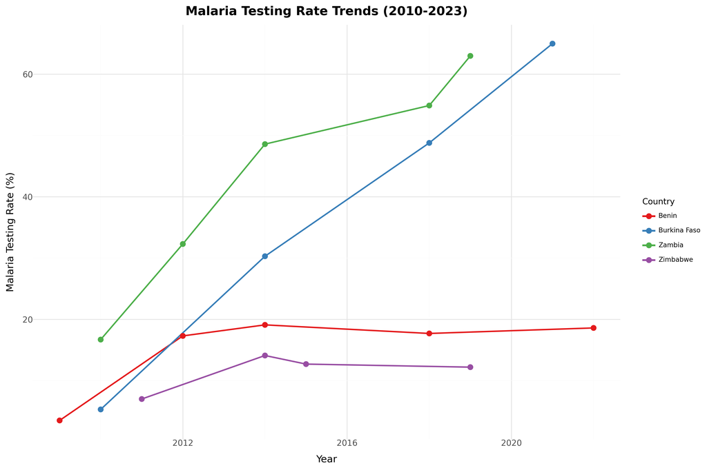

Malaria Testing Rate Trends (2010-2023)

```python
# Select countries with data across multiple years
countries_with_multiple_years = df_total.groupby('Country').filter(lambda x: len(x['Year'].unique()) >= 3)

# Select a few interesting countries for the time series
selected_countries = ['Zambia', 'Benin', 'Zimbabwe', 'Burkina Faso']
time_series_data = countries_with_multiple_years[countries_with_multiple_years['Country'].isin(selected_countries)]

# Create time series plot
time_series_plot = (
    ggplot(time_series_data, aes(x='Year', y='Malaria_Test_Percent', color='Country', group='Country')) +
    geom_line(size=1) +
    geom_point(size=3) +
    scale_color_brewer(type='qual', palette='Set1') +
    labs(
        title='Malaria Testing Rate Trends (2010-2023)',
        x='Year',
        y='Malaria Testing Rate (%)'
    ) +
    theme_minimal() +
    theme(
        plot_title=element_text(size=15, face='bold'),
        axis_text=element_text(size=10),
        axis_title=element_text(size=12),
        legend_title=element_text(size=10),
        legend_text=element_text(size=8),
        figure_size=(12, 8)
    )
)

time_series_plot.draw()
```

## Gender Analysis: Testing Rates by Sex

Understanding gender disparities in healthcare access is vital for developing inclusive policies. The following analysis compares malaria testing rates between male and female children.

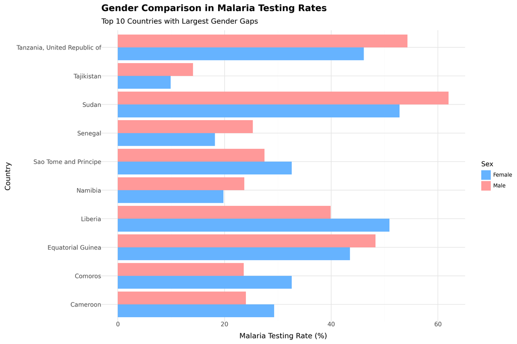

Malaria Testing Rate by Gender

```python
# Filter for data with gender information
gender_data = df[df['Sex'] != 'Total'].copy()

# Select countries with data for both genders
countries_with_both_genders = gender_data.groupby('Country')['Sex'].nunique().reset_index()
countries_with_both_genders = countries_with_both_genders[countries_with_both_genders['Sex'] == 2]['Country'].tolist()

# Filter data for these countries
gender_comparison = gender_data[gender_data['Country'].isin(countries_with_both_genders)].copy()

# Calculate the latest data for each country and gender
latest_gender_data = gender_comparison.sort_values('Year').groupby(['Country', 'Sex']).tail(1)

# Calculate gender gap
gender_pivot = latest_gender_data.pivot(index='Country', columns='Sex', values='Malaria_Test_Percent').reset_index()
gender_pivot['Gender_Gap'] = gender_pivot['Male'] - gender_pivot['Female']

# Sort by absolute gender gap
gender_pivot = gender_pivot.sort_values(by='Gender_Gap', key=abs, ascending=False).head(10)

# Reshape for plotting
plot_data = gender_pivot.melt(id_vars=['Country', 'Gender_Gap'],
                             value_vars=['Male', 'Female'],
                             var_name='Sex',
                             value_name='Testing_Rate')

# Create the plot
gender_plot = (
    ggplot(plot_data, aes(x='Country', y='Testing_Rate', fill='Sex')) +
    geom_bar(stat='identity', position='dodge') +
    scale_fill_manual(values=['#66b3ff', '#ff9999']) +
    labs(
        title='Gender Comparison in Malaria Testing Rates',
        subtitle='Top 10 Countries with Largest Gender Gaps',
        x='Country',
        y='Malaria Testing Rate (%)'
    ) +
    coord_flip() +
    theme_minimal() +
    theme(
        plot_title=element_text(size=15, face='bold'),
        plot_subtitle=element_text(size=12),
        axis_text=element_text(size=10),
        axis_title=element_text(size=12),
        figure_size=(12, 8)
    )
)

gender_plot.draw()
```

## Conclusion and Recommendations

This analysis of UNICEF malaria testing data reveals significant progress in many countries but also highlights persistent challenges and disparities. Based on our findings, we recommend:

1. **Targeted Interventions**: Focus resources on regions with lowest testing rates, using successful models from top-performing countries.
2. **Gender-Sensitive Approaches**: Address gender gaps in malaria testing through programs specifically designed to ensure equal access for all children.
3. **Economic Context Considerations**: Recognize that economic development alone doesn’t guarantee improved testing rates - targeted healthcare policies matter more.
4. **Data Collection Improvements**: Expand data collection efforts to cover more countries and gather more consistent time series data.
5. **Best Practice Sharing**: Facilitate knowledge exchange between countries like Zambia and Burkina Faso that have achieved remarkable progress and those still struggling.

By implementing these recommendations, UNICEF and partner organizations can continue to make strides in ensuring that all children, regardless of location or gender, have access to timely malaria testing and treatment.